# Aggregate Teacher Plans

A Abbott

6/27/2019

## Aggregate solvency of teacher plans

By bundling all US state teacher plans we can see the aggregate solvency of US teacher pension systems over time.

## Data import

First we need to import the data from the pensiondata.org database. I define a function here to pull data from all plans.

Next I call the new function and filter the results. The following list of state teacher plans are included in this analysis:

- Alabama Teachers
- Alaska Teachers
- Arizona SRS
- Arkansas Teachers
- California Teachers
- Colorado School
- Connecticut Teachers
- Delaware State Employees
- DC Teachers
- Florida RS
- Georgia Teachers
- Hawaii ERS
- Idaho PERS
- Illinois Teachers
- Indiana Teachers
- Iowa PERS
- Kansas PERS
- Kentucky Teachers
- Louisiana Teachers
- Maine State and Teacher
- Maryland Teachers
- Massachusetts Teachers
- Michigan Public Schools
- Minnesota Teachers
- Mississippi PERS
- Missouri Teachers
- Montana Teachers
- Nebraska Schools
- Nevada Regular Employees
- New Hampshire RS
- New Jersey Teachers
- New Mexico Educational
- New York State Teachers
- North Carolina Teachers and State Employees
- North Dakota Teachers
- Ohio Teachers
- Oklahoma Teachers
- Oregon PERS
- Pennsylvania School Employees
- Rhode Island ERS
- South Carolina RS
- South Dakota RS
- TN State and Teachers
- Texas Teachers
- Utah Noncontributory
- Vermont Teachers
- Virginia RS
- Washington Teachers Plan 2/3
- West Virginia Teachers
- Wisconsin RS
- Wyoming Public Employees

```r
teacher_aggregates <- teachers %>%
  rename(year = fy) %>%
  group_by(year) %>%
  summarize(aal = sum(ActLiabilities_GASB),
            ava = sum(ActAssets_GASB),
            uaal = sum(ActLiabilities_GASB) - sum(ActAssets_GASB),
            funded_ratio = sum(ActAssets_GASB) / sum(ActLiabilities_GASB))

debtTable(teacher_aggregates)
```

| Year | Actuarial Assets | Actuarial Accrued Liabilities | Unfunded Actuarial Accrued Liabilities | Funded Ratio |
| --- | --- | --- | --- | --- |
| 2001 | 1125863531630 | 1137456027323 | 11592495693 | 0.989808401015481 |
| 2002 | 1132050071650 | 1222045378291 | 89995306641 | 0.92635682091703 |
| 2003 | 1143212353142 | 1290284313949 | 147071960807 | 0.886015849982027 |
| 2004 | 1192612735814 | 1363682069301 | 171069333487 | 0.874553360099039 |
| 2005 | 1253566873543 | 1478185894540 | 224619020997 | 0.848044131778906 |
| 2006 | 1333342790034 | 1567870099145 | 234527309111 | 0.850416619821442 |
| 2007 | 1454959799110 | 1680509308437 | 225549509327 | 0.86578502826814 |
| 2008 | 1512751931756 | 1772938683753 | 260186751997 | 0.853245487629482 |
| 2009 | 1438617460339 | 1858630396277 | 420012935938 | 0.774020194235862 |
| 2010 | 1454569591405 | 1933825654149 | 479256062744 | 0.752172042130188 |

[output cut: 7 more lines]

## A Mountain of Debt

Now we will visualize the growing unfunded liabilites since 2001.

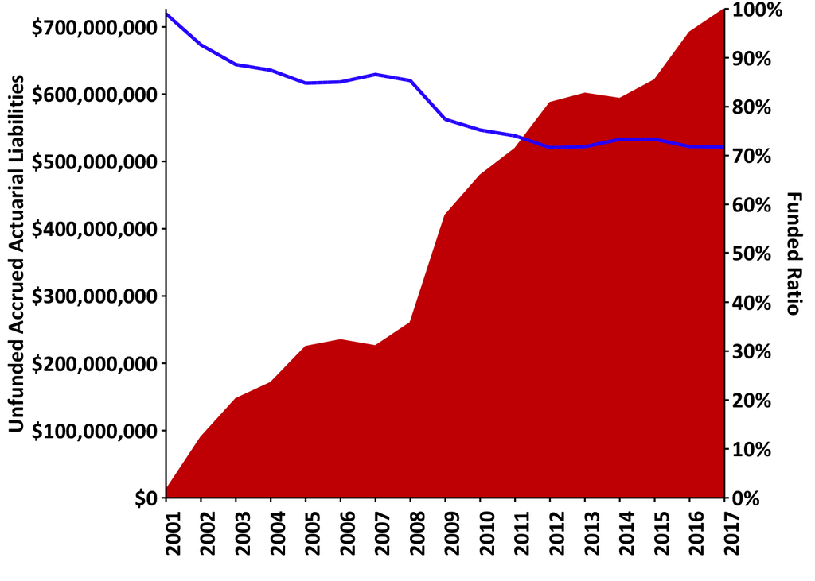

## Closer look at 2017 data

If we would like to find out which teacher plans are driving this trend and which are in the worst shape, we can do that too. I have arranged the plans by descending UAAL in 2017. By clicking on the arrow next to the column name, you can sort by other columns as well.

| Plan | Actuarial Assets | Actuarial Accrued Liabilities | Unfunded Actuarial Accrued Liabilities | Funded Ratio |
| --- | --- | --- | --- | --- |
| California Teachers | 179689000000 | 286950000000 | 107261000000 | 0.626203171284196 |
| Illinois Teachers | 49467525000 | 122904034000 | 73436509000 | 0.402489026519667 |
| Pennsylvania School Employees | 57336856000 | 101848817000 | 44511961000 | 0.562960451469947 |
| New Jersey Teachers | 26549410215 | 63028940941 | 36479530726 | 0.421225707089896 |
| Texas Teachers | 146282000000 | 181753000000 | 35471000000 | 0.804839534973288 |
| Michigan Public Schools | 47255286564 | 76693475788 | 29438189224 | 0.616157842351877 |
| Florida RS | 150593242000 | 178579116000 | 27985874000 | 0.843285852081382 |
| Georgia Teachers | 71212660000 | 95981031000 | 24768371000 | 0.741945145390239 |
| Ohio Teachers | 72216212000 | 96126440000 | 23910228000 | 0.751262732709128 |
| Massachusetts Teachers | 25638136000 | 49193503000 | 23555367000 | 0.521169147072125 |

[output cut: 41 more lines]